# Detecting Breast Cancer Rate from the Variables

Ching Yi Lam

11/16/2024

# 1 Introduction

This report focuses on analyzing the outcome of breast cancer by performing PCA, clustering analysis and LOF algorithm. The analysis begins with the description of data, perform PCA and clustering analysis, calculating LOF scores and visualizing their distribution. The goal of this analysis is to evaluate the applicability of LOF in the context of medical data. The report aims to provide insights into the density based anomaly detection techniques can support breast cancer diagnosis.

# 2 Description of Data

The synthetic cancer dataset has 600 observartions and 11 variables. There are 10 numerical variables and 1 categorical variable. This data set is collected from my professor’s teaching data repository. All of the variables do not have missing value. A detailed description of the variables is given below:

`Sample_No`: This refers to the sample number.

`Thickness_of_Clump`: Benign cells are more likely monolayers and malignant or cancerous cells are multilayer. The rating is ranged from 1 to 10. 1 indicates the lowest thickness of clump, and 10 indicates the highest of thickness of clump.

`Cell_Size_Uniformaity`: Benign cells does not vary in size and malignant or cancer cell vary in size. The rating is ranged from 1 to 10. 1 indicates the smallest size of the cell, and 10 indicates the largest size of the cell.

`Cell_Shape_Uniformaity`: Benign cells does not vary in shape and malignant or cancer cell vary in shape. The rating is ranged from 1 to 10. 1 indicates the smallest shape of the cell, and 10 indicates the largest shape of the cell.

`Marginal_Adhesion`: Benign cells are more likely stick together and cancer cells are loose or does not stick together. The rating is ranged from 1 to 10. 1 indicates the cells are more stick together, 10 indicates the cells are loose or does not stick together.

`Single_Epithelial_Cell_Size`: In benign cells, epithelial cells are normal and malignant or cancer cells are significantly enlarged. The rating is ranged from 1 to 10. 1 indicates the epithelial cells are normal, 10 indicates the cells are significantly enlarged.

`Bare_Nuclei`: In benign cells, the bare nuclei is not surrounded by cytoplasm and in cancer cells, it is surrounded by cytoplasm. The rating is ranged from 1 to 10. 1 indicates the cell is not surrounded by cytoplasm, and 10 indicates the cell is surrounded by cytoplasm.

`Bland_Chromatin`: Benign cells have uniform or fine chromatin and cancer cells have coarse chromatin. The rating is ranged from 1 to 10. 1 indicates the cells have uniform or fine chromatin, 10 indicates the cells have coarse chromatin.

`Normal_Nucleoli`: In benign cells, nucleoli is very small and in cancer cells, nucleoli is more prominent. The rating is ranged from 1 to 10. 1 indicates the nucleoli is very small, and 10 indicates the nucleoli is prominent.

`Mitoses`: In benign cells, the cell growth is normal and in cancel cells, there is abnormal cell growth. The rating is ranged from 1 to 10. 1 indicates the cell growth is normal, and 10 indicates the cell growth is abnormal.

`Outcome`: No denotes the presence of benign, and Yes denotes the presence of malignant breast cancer.

A copy of this publicly available data is stored at https://pengdsci.github.io/datasets/BreastCancer/syntheticBreastCancerData.csv.

```r
breast = read.csv("https://pengdsci.github.io/datasets/BreastCancer/syntheticBreastCancerData.csv", stringsAsFactors = TRUE)
summary(breast)
```

```
   Sample_No     Thickness_of_Clump Cell_Size_Uniformity Cell_Shape_Uniformity
 Min.   :  1.0   Min.   : 1.00      Min.   : 1.000       Min.   : 1.000
 1st Qu.:150.8   1st Qu.: 3.00      1st Qu.: 2.000       1st Qu.: 2.000
 Median :300.5   Median : 5.00      Median : 3.000       Median : 3.000
 Mean   :300.5   Mean   : 5.41      Mean   : 4.122       Mean   : 4.195
 3rd Qu.:450.2   3rd Qu.: 7.25      3rd Qu.: 6.000       3rd Qu.: 6.000
 Max.   :600.0   Max.   :10.00      Max.   :10.000       Max.   :10.000
 Marginal_Adhesion Single_Epithelial_Cell_Size  Bare_Nuclei   Bland_Chromatin
 Min.   : 1.000    Min.   : 1.000              Min.   : 1.0   Min.   : 1.000
 1st Qu.: 2.000    1st Qu.: 3.000              1st Qu.: 2.0   1st Qu.: 3.000
 Median : 3.000    Median : 4.000              Median : 3.0   Median : 4.000
 Mean   : 3.763    Mean   : 4.293              Mean   : 4.5   Mean   : 4.495
 3rd Qu.: 5.000    3rd Qu.: 5.000              3rd Qu.: 9.0   3rd Qu.: 6.000
 Max.   :10.000    Max.   :10.000              Max.   :10.0   Max.   :10.000
 Normal_Nucleoli     Mitoses       Outcome
 Min.   : 1.000   Min.   : 1.000   No :380
 1st Qu.: 2.000   1st Qu.: 1.000   Yes:220
 Median : 3.000   Median : 2.000
 Mean   : 3.812   Mean   : 2.093
 3rd Qu.: 5.000   3rd Qu.: 2.000
 Max.   :10.000   Max.   :10.000
```

## 2.1 Summary of Categorical Data

In this section, we see the summary of the outcome.

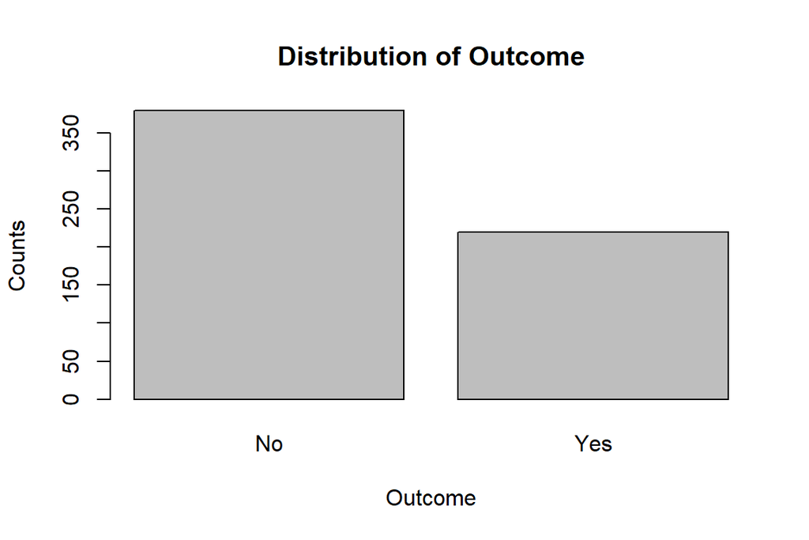

```r
freq.tbl_1 = table(breast$Outcome)
barplot(freq.tbl_1, xlab="Outcome", ylab = "Counts", main="Distribution of Outcome")
```

- The graph above represents the distribution of outcome of the breast cancer. Most people do not have breast cancer.

## 2.2 Summary of Numerical Variables

In this section, we see the summary of the 10 numerical variables.

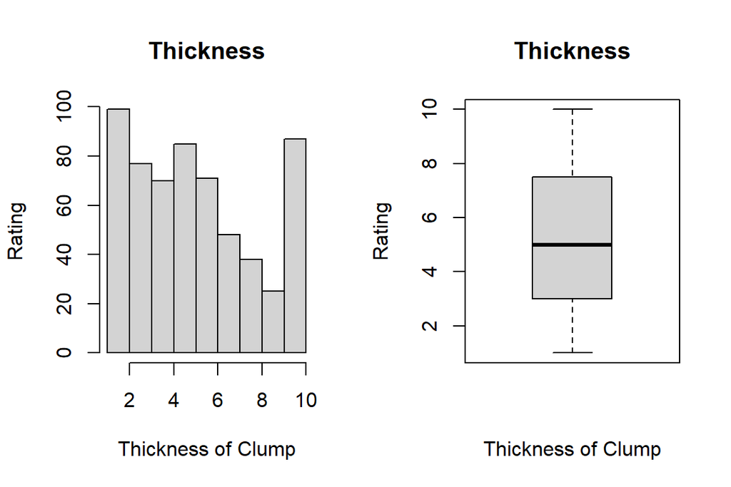

```r
par(mfrow=c(1,2))
hist(breast$Thickness_of_Clump, xlab = "Thickness of Clump", ylab = "Rating", main = "Thickness")
boxplot(breast$Thickness_of_Clump, xlab = "Thickness of Clump", ylab = "Rating", main = "Thickness")
```

- The above graphs show the distribution of thickness of clump. We see that the thickness of clump is equally distributed but it is not normal, it is bimodal.

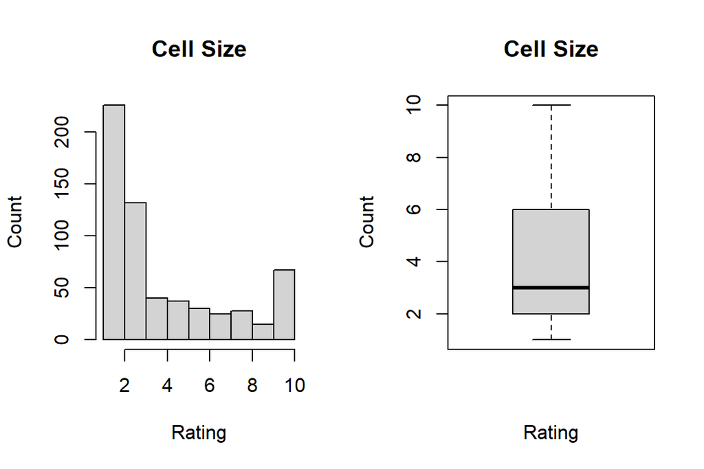

```r
par(mfrow=c(1,2))
hist(breast$Cell_Size_Uniformity, xlab = "Rating", ylab = "Count", main = "Cell Size")
boxplot(breast$Cell_Size_Uniformity, xlab = "Rating", ylab = "Count", main = "Cell Size")
```

- The above graphs show the distribution of the cell size. It shows that the graph is skewed to the right. It is bimodal, and it is not normally distributed.

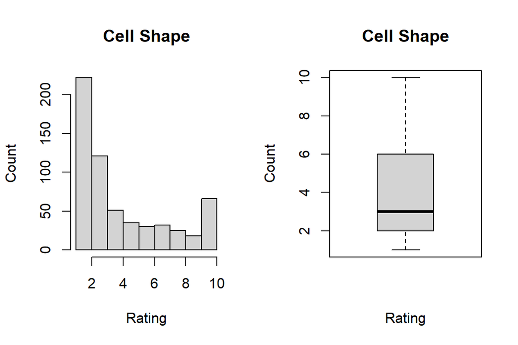

```r
par(mfrow=c(1,2))
hist(breast$Cell_Shape_Uniformity, xlab = "Rating", ylab = "Count", main = "Cell Shape")
boxplot(breast$Cell_Shape_Uniformity, xlab = "Rating", ylab = "Count", main = "Cell Shape")
```

- The above graphs show the distribution of the cell shape. It shows that the graph is skewed to the right. It is bimodal, and it is not normally distributed.

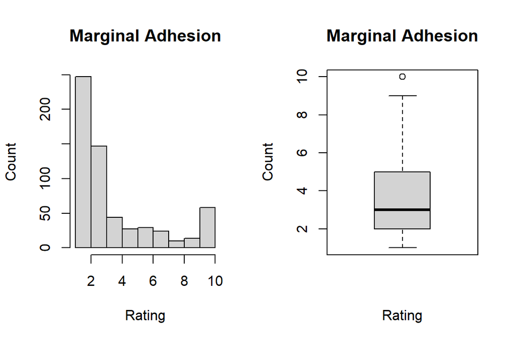

```r
par(mfrow=c(1,2))
hist(breast$Marginal_Adhesion, xlab = "Rating", ylab = "Count", main = "Marginal Adhesion")
boxplot(breast$Marginal_Adhesion, xlab = "Rating", ylab = "Count", main = "Marginal Adhesion")
```

- The above graphs show the distribution of the marginal adhesion. It shows that the graph is skewed to the right. It is bimodal, and it is not normally distributed. There is an outlier in this variable.

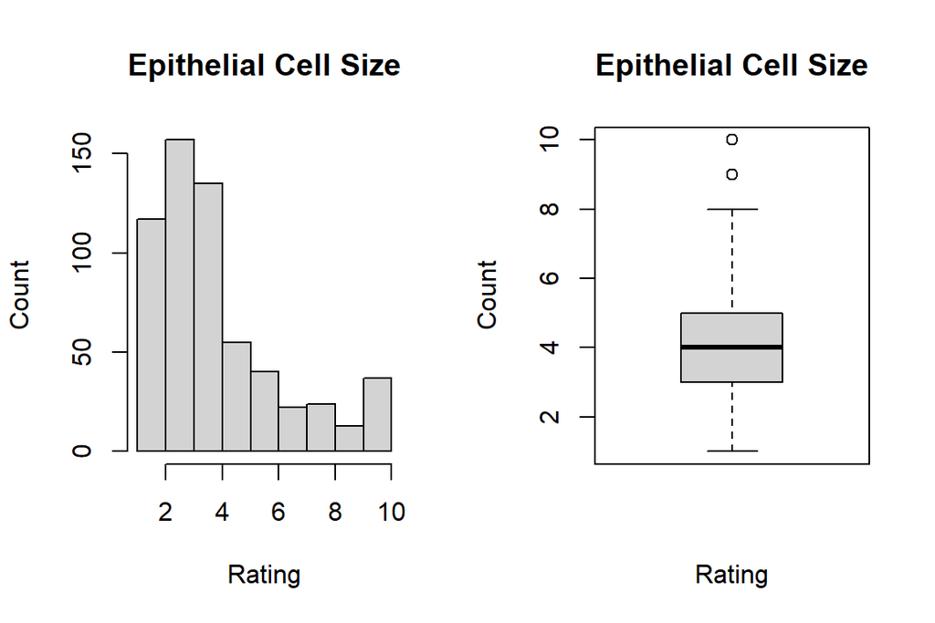

```r
par(mfrow=c(1,2))
hist(breast$Single_Epithelial_Cell_Size, xlab = "Rating", ylab = "Count", main = "Epithelial Cell Size")
boxplot(breast$Single_Epithelial_Cell_Size, xlab = "Rating", ylab = "Count", main = "Epithelial Cell Size")
```

- The above graphs show the distribution of epithelial cell size. We see that the epithelial cell size is not normally distributed and skewed to the right, it is bimodal. There is two outliers.

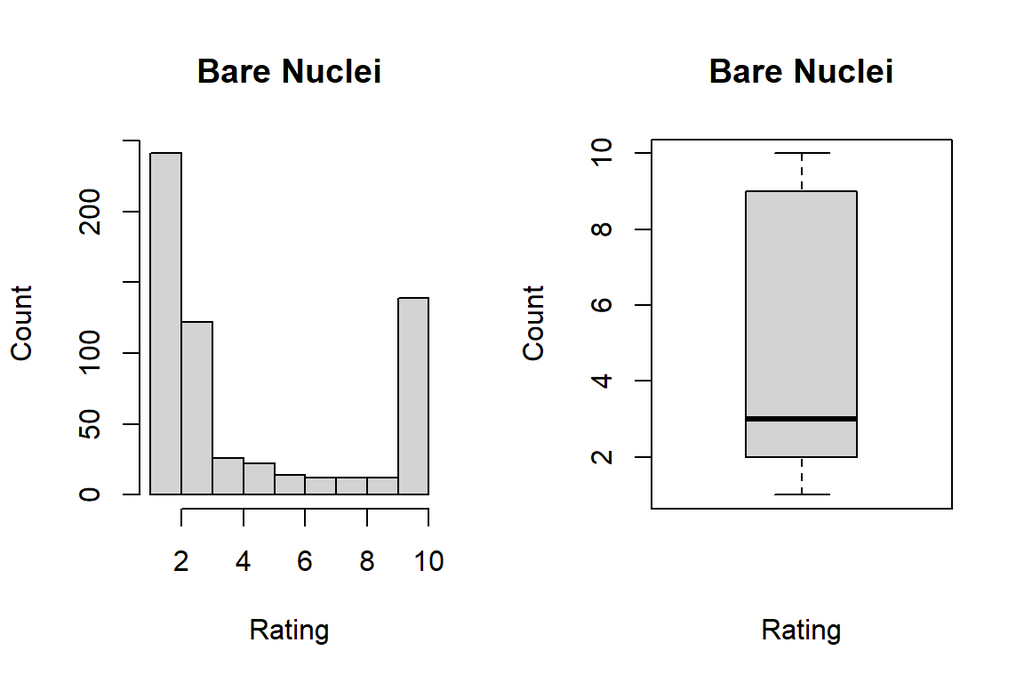

```r
par(mfrow=c(1,2))
hist(breast$Bare_Nuclei, xlab = "Rating", ylab = "Count", main = "Bare Nuclei")
boxplot(breast$Bare_Nuclei, xlab = "Rating", ylab = "Count", main = "Bare Nuclei")
```

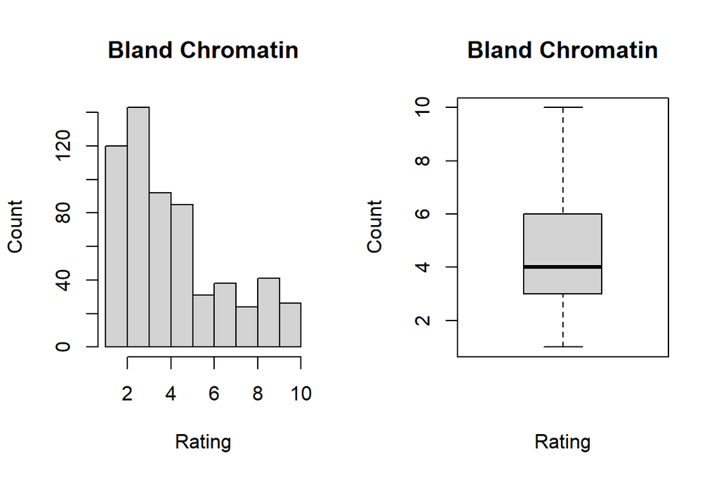

```r
par(mfrow=c(1,2))
hist(breast$Bland_Chromatin, xlab = "Rating", ylab = "Count", main = "Bland Chromatin")
boxplot(breast$Bland_Chromatin, xlab = "Rating", ylab = "Count", main = "Bland Chromatin")
```

- The graphs above show us the distribution of bland chromatin. For the histogram, we see that the diagram is skewed to the right and it is bimodal.

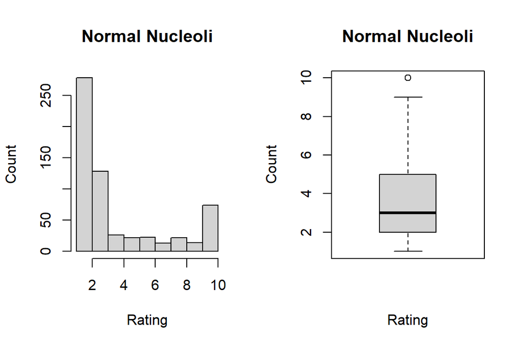

```r
par(mfrow=c(1,2))
hist(breast$Normal_Nucleoli, xlab = "Rating", ylab = "Count", main = "Normal Nucleoli")
boxplot(breast$Normal_Nucleoli, xlab = "Rating", ylab = "Count", main = "Normal Nucleoli")
```

- The graphs above show the distribution of normal nucleoli. The histogram shows that it skewed to the right and it is not normally distributed. There is an outlier.

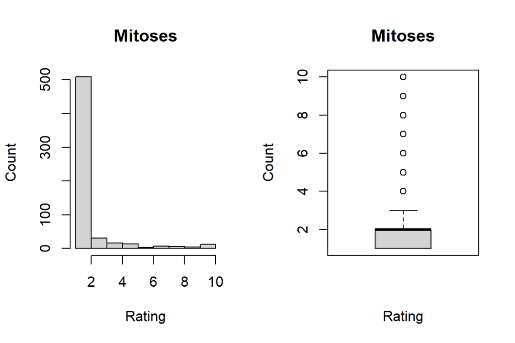

```r
par(mfrow=c(1,2))
hist(breast$Mitoses, xlab = "Rating", ylab = "Count", main = "Mitoses")
boxplot(breast$Mitoses, xlab = "Rating", ylab = "Count", main = "Mitoses")
```

- The graphs above show us the distribution of mitoses. The histogram shows the diagram is skewed to the right. There is seven outliers.

## 2.3 Subsetting and Scaling Data

Because the boxplot for all the numerical variables are skewed to the right, we use min-max scaling method to scale all the numerical variables in the dataset.

```r
## feature scaling
breast$Thickness_of_Clump.scale = (breast$Thickness_of_Clump-min(breast$Thickness_of_Clump))/(max(breast$Thickness_of_Clump) - min(breast$Thickness_of_Clump))

breast$Cell_Size_Uniformity.scale = (breast$Cell_Size_Uniformity-min(breast$Cell_Size_Uniformity))/(max(breast$Cell_Size_Uniformity) - min(breast$Cell_Size_Uniformity))

breast$Cell_Shape_Uniformity.scale = (breast$Cell_Shape_Uniformity-min(breast$Cell_Shape_Uniformity))/(max(breast$Cell_Shape_Uniformity) - min(breast$Cell_Shape_Uniformity))

breast$Marginal_Adhesion.scale = (breast$Marginal_Adhesion-min(breast$Marginal_Adhesion))/(max(breast$Marginal_Adhesion) - min(breast$Marginal_Adhesion))

breast$Single_Epithelial_Cell_Size.scale = (breast$Single_Epithelial_Cell_Size-min(breast$Single_Epithelial_Cell_Size))/(max(breast$Single_Epithelial_Cell_Size) - min(breast$Single_Epithelial_Cell_Size))

breast$Bare_Nuclei.scale = (breast$Bare_Nuclei-min(breast$Bare_Nuclei))/(max(breast$Bare_Nuclei) - min(breast$Bare_Nuclei))

breast$Bland_Chromatin.scale = (breast$Bland_Chromatin-min(breast$Bland_Chromatin))/(max(breast$Bland_Chromatin) - min(breast$Bland_Chromatin))

breast$Normal_Nucleoli.scale = (breast$Normal_Nucleoli-min(breast$Normal_Nucleoli))/(max(breast$Normal_Nucleoli) - min(breast$Normal_Nucleoli))

breast$Mitoses.scale = (breast$Mitoses-min(breast$Mitoses))/(max(breast$Mitoses) - min(breast$Mitoses))
```

# 3 Logistic Regression Analysis

The purpose of the logistic regression analysis is to find out if we can use the predictor variables to predict our response variable: Outcome. The purpose of this analysis will be a predictive analysis.

The response variable: Outcome

Predictor variables:

- Thickness of Clump
- Cell Size Uniformity
- Cell Shape Uniformity
- Marginal Adhesion
- Single Epithelial Cell Size
- Bare Nuclei
- Bland Chromatin
- Normal Nucleoli
- Mitoses

Here below we are trying to build the initial model.

- **Build an Initial Model**

First, we build a logistic regression model that contains all predictor variables in the dataset. This model called the initial model.

```r
initial.model = glm(Outcome ~ Thickness_of_Clump + Cell_Size_Uniformity + Cell_Shape_Uniformity + Marginal_Adhesion + Single_Epithelial_Cell_Size + Bare_Nuclei + Bland_Chromatin + Normal_Nucleoli + Mitoses, family = binomial, data = breast)
coefficient.table = summary(initial.model)$coef
kable(coefficient.table, caption = "Significance tests of logistic regression model")
```

Significance tests of logistic regression model

|  | Estimate | Std. Error | z value | Pr(>\|z\|) |
| --- | --- | --- | --- | --- |
| (Intercept) | -11.3994839 | 1.2546649 | -9.0856797 | 0.0000000 |
| Thickness_of_Clump | 0.4669781 | 0.1257561 | 3.7133626 | 0.0002045 |
| Cell_Size_Uniformity | 0.0313879 | 0.1567402 | 0.2002543 | 0.8412817 |
| Cell_Shape_Uniformity | 0.3685873 | 0.1686559 | 2.1854394 | 0.0288566 |
| Marginal_Adhesion | 0.1968390 | 0.1111111 | 1.7715519 | 0.0764690 |
| Single_Epithelial_Cell_Size | 0.0760556 | 0.1391434 | 0.5465989 | 0.5846543 |
| Bare_Nuclei | 0.4282675 | 0.0871709 | 4.9129632 | 0.0000009 |
| Bland_Chromatin | 0.3640725 | 0.1365713 | 2.6658054 | 0.0076804 |
| Normal_Nucleoli | 0.1406214 | 0.1015091 | 1.3853083 | 0.1659582 |
| Mitoses | 0.4012046 | 0.2317122 | 1.7314786 | 0.0833664 |

The p-value of thickness of clump, cell shape uniformity, bare nuclei, and bland chromatin is smaller than alpha = 0.05. We have significant evidence to indicate that these 4 variables can predict the outcome of breast cancer. Next, we search for the best model using automatic variable procedure to search the final model.

- **Automatic Variable Selection**

The cell size is practically important, we will include this variable in the final model regardless of the statistical significance.

In summary, we define two models: the full model and the reduced model. The final optimal model will be chosen between these two models. A summary table of the significant tests is provided below.

```r
full.model = initial.model
reduced.model = glm(Outcome ~ Cell_Size_Uniformity , family = binomial, data = breast)
backward.model =  step(full.model,
                    scope=list(lower=formula(reduced.model),upper=formula(full.model)),
                    data = breast,
                    direction = "backward",
                    trace = 0)
final.model.coef = summary(backward.model)$coef
kable(final.model.coef , caption = "Summary table of significant tests")
```

Summary table of significant tests

|  | Estimate | Std. Error | z value | Pr(>\|z\|) |
| --- | --- | --- | --- | --- |
| (Intercept) | -11.3030525 | 1.2370762 | -9.1369089 | 0.0000000 |
| Thickness_of_Clump | 0.4679409 | 0.1258717 | 3.7176016 | 0.0002011 |
| Cell_Size_Uniformity | 0.0483493 | 0.1532623 | 0.3154674 | 0.7524068 |
| Cell_Shape_Uniformity | 0.3730796 | 0.1694079 | 2.2022566 | 0.0276472 |
| Marginal_Adhesion | 0.2103724 | 0.1083512 | 1.9415781 | 0.0521882 |
| Bare_Nuclei | 0.4305387 | 0.0876169 | 4.9138792 | 0.0000009 |
| Bland_Chromatin | 0.3712557 | 0.1361776 | 2.7262609 | 0.0064056 |
| Normal_Nucleoli | 0.1541708 | 0.0991788 | 1.5544727 | 0.1200717 |
| Mitoses | 0.4093731 | 0.2276841 | 1.7979871 | 0.0721791 |

- **Interpretation**

The p-value of thickness of clump, cell shape uniformity, bare nuclei, and bland chromatin is smaller than alpha = 0.05 which means they are significant in predicting the response variable: outcome of having breast cancer or not.

- **Predictive Analysis**

We use the final model to predict the status of successful introduction based on the updated predictor variable values for two individuals.

```r
mynewdata = data.frame(Thickness_of_Clump =c(3, 8),
                       Cell_Size_Uniformity = c(5, 7),
                       Cell_Shape_Uniformity = c(7,4),
                       Marginal_Adhesion = c(5, 5),
                       Bare_Nuclei = c(7 ,5),
                       Bland_Chromatin = c(2 ,6),
                       Normal_Nucleoli = c(6, 8),
                       Mitoses = c(7 ,3))
pred.success.prob = predict(backward.model, newdata = mynewdata, type="response")
##
## threshold probability
cut.off.prob = 0.5
pred.response = ifelse(pred.success.prob > cut.off.prob, 1, 0)  # This predicts the response
## Add the new predicted response to Mynewdata
mynewdata$Pred.Response = pred.response
##
kable(mynewdata, caption = "Predicted Value of response variable
      with the given cut-off probability")
```

Predicted Value of response variable with the given cut-off probability

| Thickness_of_Clump | Cell_Size_Uniformity | Cell_Shape_Uniformity | Marginal_Adhesion | Bare_Nuclei | Bland_Chromatin | Normal_Nucleoli | Mitoses | Pred.Response |
| --- | --- | --- | --- | --- | --- | --- | --- | --- |
| 3 | 5 | 7 | 5 | 7 | 2 | 6 | 7 | 1 |
| 8 | 7 | 4 | 5 | 5 | 6 | 8 | 3 | 1 |

We used random value to test if the model can predict the person has breast cancer or not. This is the predicted status of the successful introduction of the two individuals is attached to the two new records.

# 4 Hierarchical Clustering Analysis

We choose hierarchical clustering over k-means clustering is because hierarchical clustering does not require specifying the number of clusters in advance while k-means clustering requires pre-specifying the number of clusters, which we may not be known beforehand.

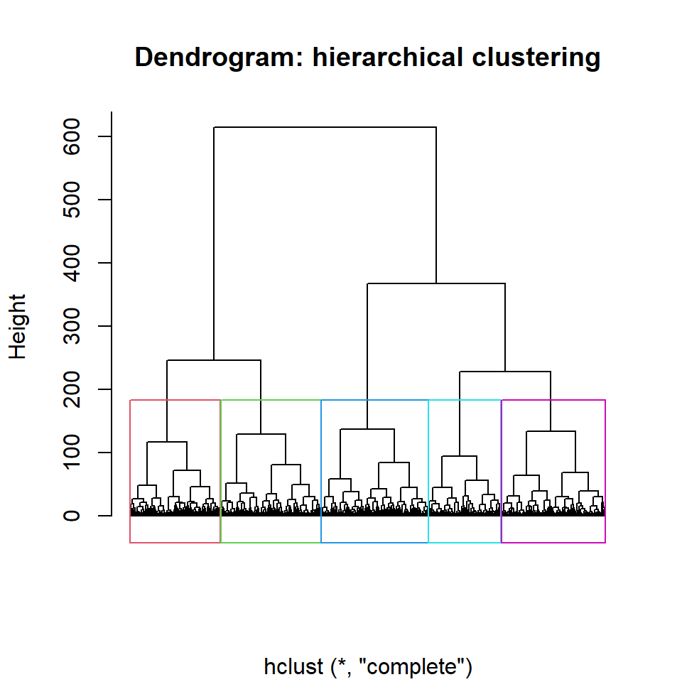

Dendrogram: hierarchical clustering

```r
scales.hierarch = as.data.frame(breast)
distance <- dist(scales.hierarch, method = "euclidean")
# Hierarchical clustering using Complete Linkage
hc1 <- hclust(distance, method = "complete" )
# Plot the obtained dendrogram
plot(hc1, cex = 0.6, labels = FALSE, hang = -1, xlab = "", main = "Dendrogram: hierarchical clustering")
rect.hclust(hc1, k = 5, border = 2:9)
```

In this dendrogram, the tree is cut at a height that produces 5 clusters. At a low height, individual data points are grouped into small clusters. At a high height, those small clusters are further merged into larger clusters.

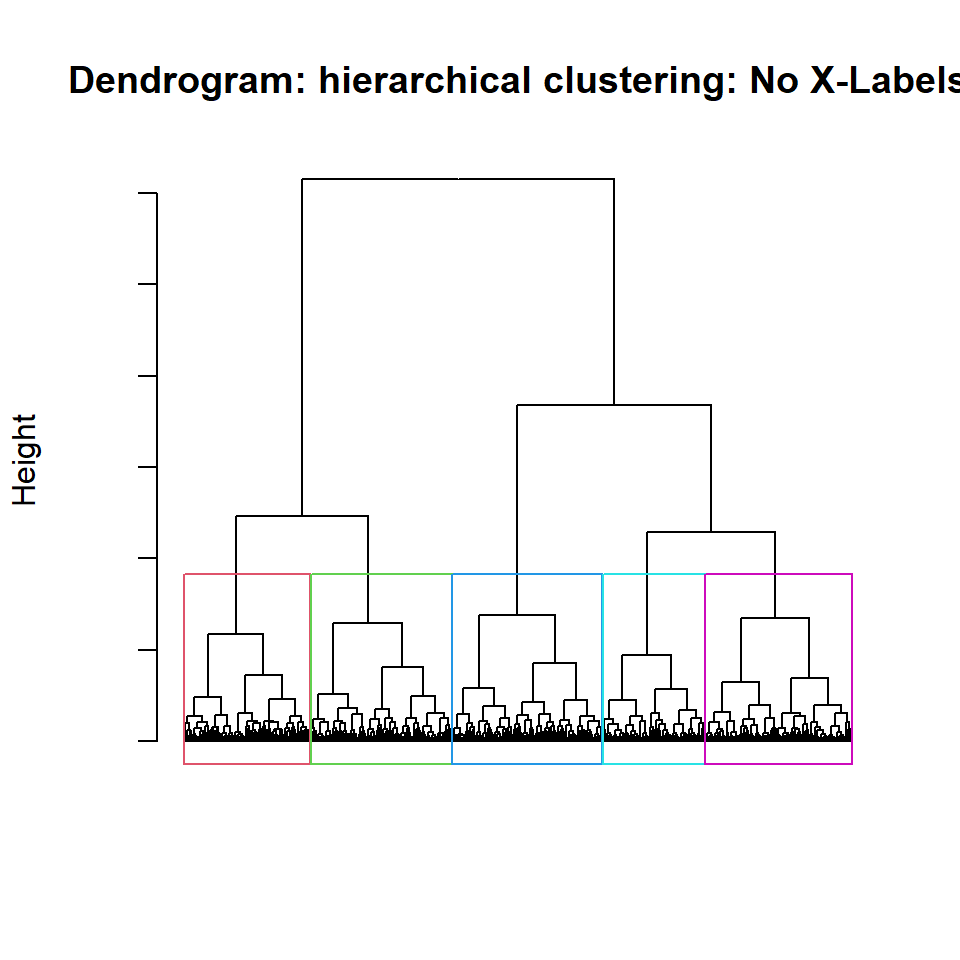

Dendrogram: hierarchical clustering: No X-Labels

```r
# Figured this out by coloring the labels white to the background
avg_dend_obj <- as.dendrogram(hc1)
labels_colors(avg_dend_obj) <- "white"
plot(avg_dend_obj, cex = 0.6,
     labels = FALSE,
     hang = -1,
     xlab = "",
     ylab= "Height",
     main = "Dendrogram: hierarchical clustering: No X-Labels")
rect.hclust(hc1, k = 5, border = 2:9)
```

This dendrogram is a simplified version to improve interpretability when the dataset has a large number of points. It retains the hierarchical relationship and the ability to define clusters visually while omitting the potentially cluttered x-axis labels.

## 4.1 Determination Optimal Number of Clusters

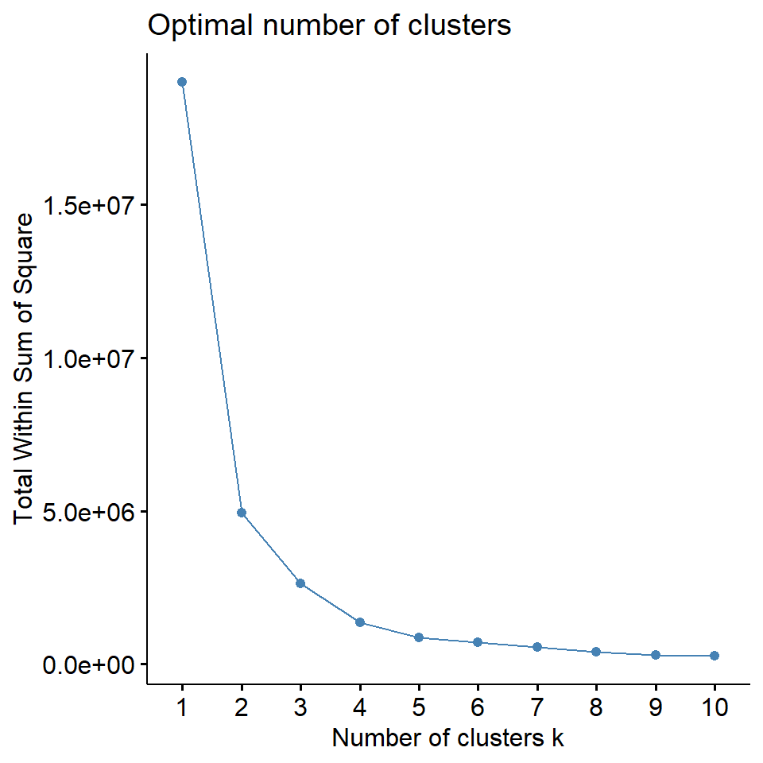

Elbow plot: Optimal number of clusters

```r
fviz_nbclust(scales.hierarch, FUN = hcut, method = "wss")
```

This Elbow plot above helps identify the trade-off between the number of clusters and the clustering quality. Based on the plot, we would test the clustering results for k = 2 or k = 3 and choose one that aligns better. Next, we will do a Silhouette plot to find out which number of clustering is better for our model.

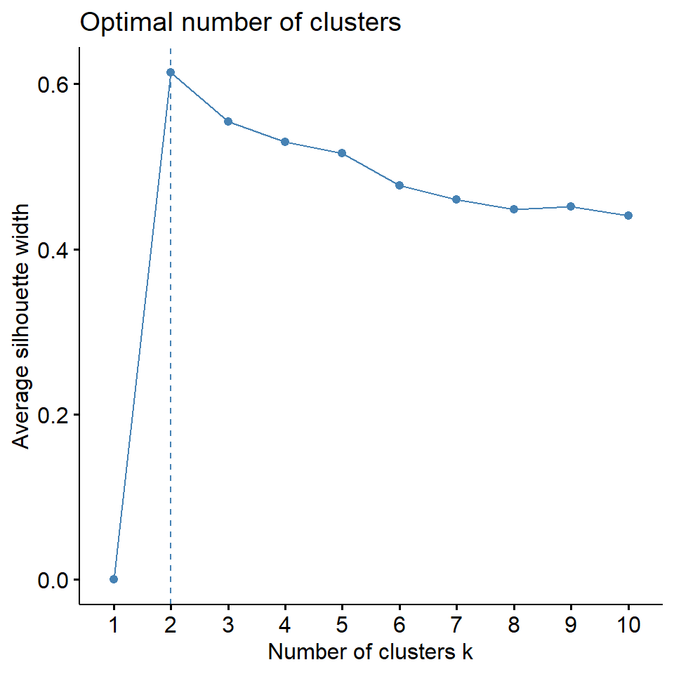

Silhouette plot: Optimal number of clusters

```r
fviz_nbclust(scales.hierarch, FUN = hcut, method = "silhouette")
```

The number of clusters for this Silhouette plot is k = 2 based on the peak in the width, meaning the data points are most cohesively and distinctly grouped with 2 clusters.

## 4.2 Extracting Cluster ID

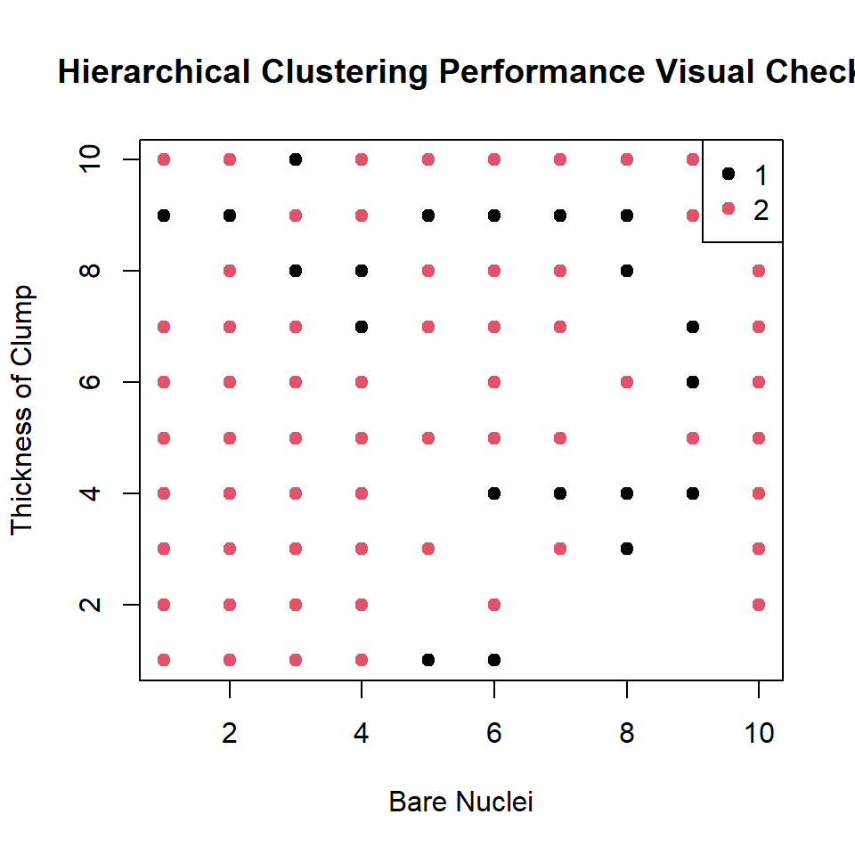

Visual check the resulting clusters obtained from agglomerative hierarchical clustering.

```r
hc4 <- hclust(distance, method = "complete" )
Outcome = cutree(hc4, k = 2)
scales.hierarch$Outcome = Outcome
##
plot(scales.hierarch$Bare_Nuclei, scales.hierarch$Thickness_of_Clump,
     pch = 19,
     col = factor(scales.hierarch$Outcome),
     xlab ="Bare Nuclei",
     ylab = "Thickness of Clump",
     main = "Hierarchical Clustering Performance Visual Check")

## Legend
legend("topright",
       legend = levels(factor(scales.hierarch$Outcome)),
       pch = 19,
       col = factor(levels(factor(scales.hierarch$Outcome))))
```

# 5 Principal Component Analysis (PCA)

```r
breast.drop = subset(breast, select = -c(Outcome, Sample_No, Thickness_of_Clump.scale, Cell_Size_Uniformity.scale, Cell_Shape_Uniformity.scale, Marginal_Adhesion.scale, Single_Epithelial_Cell_Size.scale, Bare_Nuclei.scale, Bland_Chromatin.scale, Normal_Nucleoli.scale, Mitoses.scale))
```

```r
log.breast = log(breast.drop)   # drop the categorical variable in the original
                            # data set and transform all numerical to the
                            # log-scale
ir.pca <- prcomp(log.breast, center = TRUE, scale = TRUE)
# summary(ir.pca)[6]   # use the command to explore the possible information
                       # available in the output of the summary.
```

```r
kable(round(ir.pca$rotation, 2), caption="Factor loadings of the PCA")
```

Factor loadings of the PCA

|  | PC1 | PC2 | PC3 | PC4 | PC5 | PC6 | PC7 | PC8 | PC9 |
| --- | --- | --- | --- | --- | --- | --- | --- | --- | --- |
| Thickness_of_Clump | -0.30 | 0.00 | 0.81 | 0.26 | -0.34 | 0.07 | -0.20 | -0.14 | 0.08 |
| Cell_Size_Uniformity | -0.38 | -0.09 | 0.02 | 0.03 | 0.19 | 0.15 | 0.24 | 0.57 | 0.64 |
| Cell_Shape_Uniformity | -0.38 | -0.08 | 0.16 | 0.00 | 0.18 | -0.04 | 0.36 | 0.35 | -0.73 |
| Marginal_Adhesion | -0.32 | -0.14 | -0.39 | 0.71 | 0.15 | -0.01 | -0.43 | -0.03 | -0.09 |
| Single_Epithelial_Cell_Size | -0.34 | 0.08 | 0.12 | -0.41 | 0.65 | 0.23 | -0.31 | -0.35 | 0.01 |
| Bare_Nuclei | -0.36 | -0.10 | -0.19 | 0.10 | -0.12 | 0.01 | 0.62 | -0.63 | 0.13 |
| Bland_Chromatin | -0.32 | -0.27 | -0.30 | -0.41 | -0.56 | 0.41 | -0.25 | 0.09 | -0.11 |
| Normal_Nucleoli | -0.34 | -0.03 | -0.06 | -0.28 | -0.12 | -0.86 | -0.19 | 0.02 | 0.10 |
| Mitoses | -0.23 | 0.94 | -0.16 | 0.03 | -0.18 | 0.08 | 0.00 | 0.06 | -0.03 |

- For PC1, the variables Cell Size Uniformity, Cell Shape Uniformity and Bare Nuclei have the largest negative contributions which means they dominate this component.
- For PC2, the variable Mitoses has the largest positive contribution which indicates that it strongly influences this component.

## 5.1 Optimal number of PCs to be retained

The following summary table gives the importance of the principal components.

```r
kable(summary(ir.pca)$importance, caption="The importance of each principal component")
```

The importance of each principal component

|  | PC1 | PC2 | PC3 | PC4 | PC5 | PC6 | PC7 | PC8 | PC9 |
| --- | --- | --- | --- | --- | --- | --- | --- | --- | --- |
| Standard deviation | 2.236848 | 0.8861556 | 0.807164 | 0.7348774 | 0.7034302 | 0.6886101 | 0.6395409 | 0.6102888 | 0.5188643 |
| Proportion of Variance | 0.555940 | 0.0872500 | 0.072390 | 0.0600000 | 0.0549800 | 0.0526900 | 0.0454500 | 0.0413800 | 0.0299100 |
| Cumulative Proportion | 0.555940 | 0.6432000 | 0.715590 | 0.7755900 | 0.8305700 | 0.8832600 | 0.9287000 | 0.9700900 | 1.0000000 |

From the table above, we can see that the first principal component explains about 55.59% if the total variance in the dataset. The first two principal components (PC1 and PC2) explain about 64.32% of the total variation. If we include eight components (PC1 to PC8), they explain about 97% of the total variance. In the data analysis, we need to use eight components that lose about 3% of the information.

We can also make a scree plot as a visual tool to show the number of principal components to retain for future analysis.

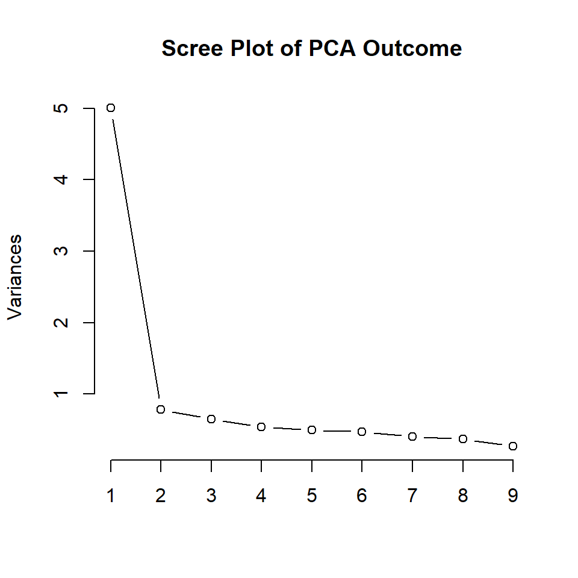

```r
screeplot(ir.pca,
          type = "lines",
          main = "Scree Plot of PCA Outcome")
```

The vertical axis in the above scree plot uses the variances of PCs. The standard deviation was used in the above summary table.

# 6 Local Outlier Factor (LOF) Method: Outlier Detection

To assess the performance of LOF, we need to perform a supervised classification analysis using the variable: Outcome to detect the outcome of the breast cancer. The actual outcome rate pf this dataset is 220 / 600 ≈ 0.3666666 = 36.67%. Any models that have a detection rate greater than 36.67 are worthwhile.

## 6.1 Distribution of LOF

The distribution of LOF scores is heavily skewed to the right. The results summarize and visualize the distribution of LOF scores are below.

```r
lof.breast <- lof(as.matrix(breast[, c(12, 13, 14, 15, 16, 17, 18, 19, 20)]), minPts = 100)
summary(lof.breast)
```

```
   Min. 1st Qu.  Median    Mean 3rd Qu.    Max.
 0.9658  0.9955  1.0190  1.0917  1.0890  2.2691
```

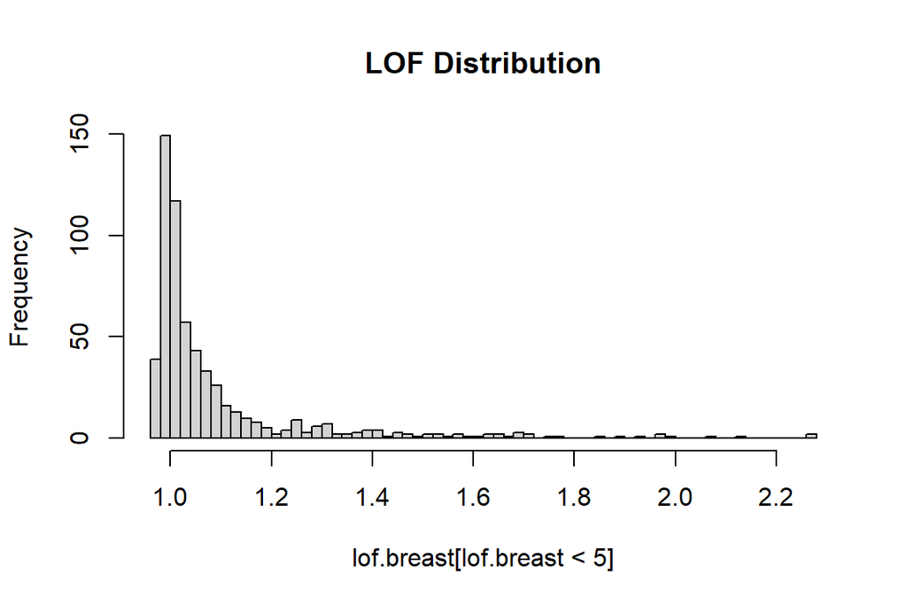

```r
hist(lof.breast[lof.breast < 5], breaks = 50, main = "LOF Distribution")
```

## 6.2 Predictive Power of LOF Score

In the following figure, we choose a sequence of TOF cut-offs and plot the relative improvement rate against LOF scores to show the “performance of detection”.

```r
# We create the ID variable to build our model.
breast$OutcomeID <- as.numeric(breast$Outcome)

# 1 = No, 2 = Yes
```

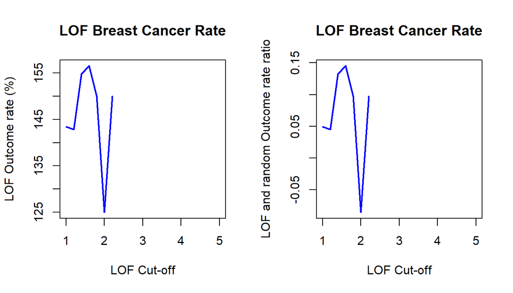

```r
## Choose a sequence of cut-offs of LOF scores
cut.lof = seq(1,5, length = 21)
##
lof.outcome.rate = NULL
for (i in 1:length(cut.lof)){
  ID = lof.breast > cut.lof[i]
  OutcomeID = breast$OutcomeID[ID]
  lof.outcome.rate[i] = sum(OutcomeID )/sum(ID)
}
##
defaultOutcomeRate = sum(breast$OutcomeID)/length(breast$OutcomeID)
rel.detect.rate = (lof.outcome.rate-defaultOutcomeRate)/defaultOutcomeRate
##
par(mfrow=c(1,2))
plot( cut.lof, 100*lof.outcome.rate, type = "l", col = "blue", lwd = 2,
      xlab = "LOF Cut-off",
      ylab = "LOF Outcome rate (%)",
      main = "LOF Breast Cancer Rate")
plot( cut.lof, rel.detect.rate, type = "l", col = "blue", lwd=2,
      xlab = "LOF Cut-off",
      ylab = "LOF and random Outcome rate ratio",
      main = "LOF Breast Cancer Rate")
```

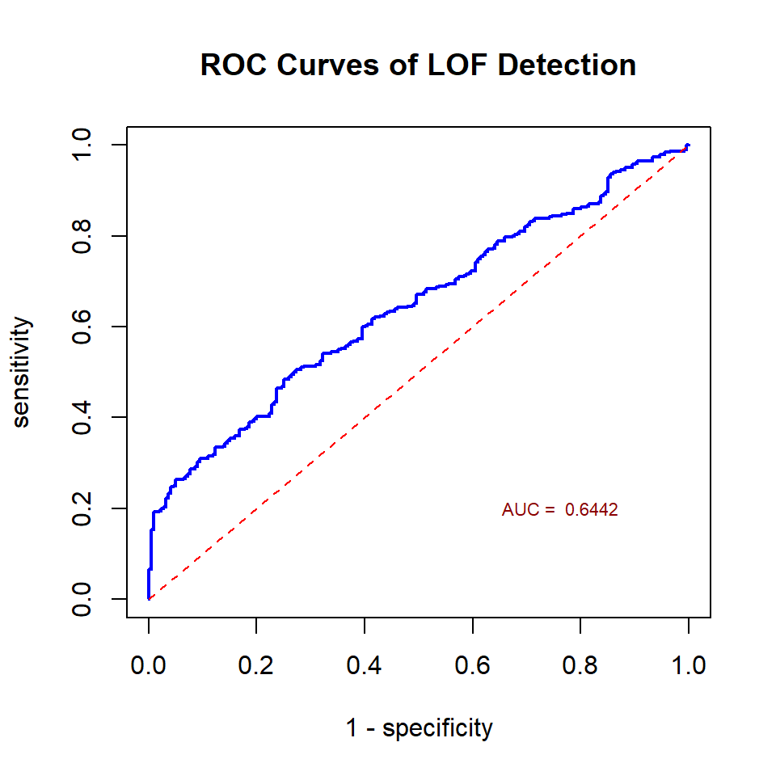

```r
#cutloff = seq(1,15, length = 20)
#pred.lof.100 = as.numeric(lof.fraud.00 > cut.lof[i])
  category  = as.character(breast$OutcomeID)
  ROCobj.lof <- roc(category, lof.breast, levels=c("2", "1"),direction = ">")
  ##
  sen.LOF = ROCobj.lof$sensitivities
  fnr.LOF = 1 - ROCobj.lof$specificities
par(type="s")
plot(fnr.LOF, sen.LOF , type = "l", lwd = 2, col = "blue",
     xlim = c(0,1),
     ylim = c(0,1),
     xlab = "1 - specificity",
     ylab = "sensitivity",
     main = "ROC Curves of LOF Detection")
segments(0,0,1,1, lwd =1, col = "red", lty = 2)
AUC = ROCobj.lof$auc
text(0.87, 0.20, paste("AUC = ", round(AUC,4)), col="darkred", cex = 0.7, adj = 1)
```

The area under the ROC curve is about 0.64 indicating a moderate predicting power of LOF scores.

## 6.3 Tuning Hyperparameter k

```r
lof.breast.50  <- lof(as.matrix(breast[, c(12, 13, 14, 15, 16, 17, 18, 19, 20)]), minPts = 50)
lof.breast.200  <- lof(as.matrix(breast[, c(12, 13, 14, 15, 16, 17, 18, 19, 20)]), minPts = 200)
lof.breast.400  <- lof(as.matrix(breast[, c(12, 13, 14, 15, 16, 17, 18, 19, 20)]), minPts = 400)
```

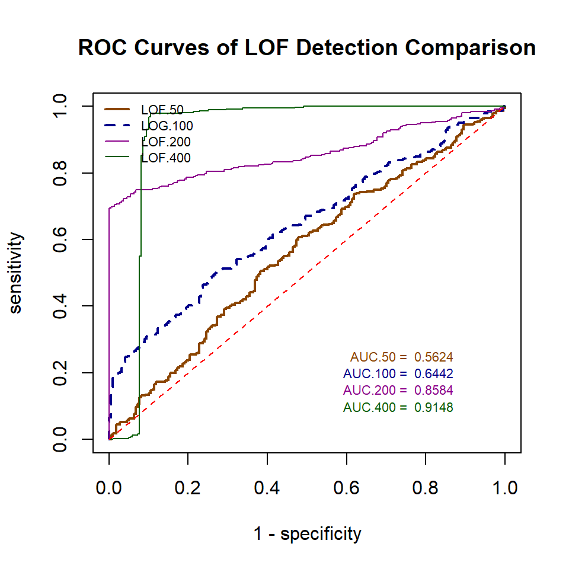

```r
  #category = as.character(fraud$isFraud)
  ROCobj.lof.50 <- roc(category, lof.breast.50, levels=c("2", "1"), direction = ">")
  ROCobj.lof.100 <- roc(category, lof.breast, levels=c("2", "1"), direction = ">")
  ROCobj.lof.200 <- roc(category, lof.breast.200, levels=c("2", "1"), direction = ">")
  ROCobj.lof.400 <- roc(category, lof.breast.400, levels=c("2", "1"), direction = ">")
  ##
  sen.LOF.50 = ROCobj.lof.50$sensitivities
  fnr.LOF.50 = 1 - ROCobj.lof.50$specificities
  ##
  sen.LOF.100 = ROCobj.lof.100$sensitivities
  fnr.LOF.100 = 1 - ROCobj.lof.100$specificities
  ##
  sen.LOF.200 = ROCobj.lof.200$sensitivities
  fnr.LOF.200 = 1 - ROCobj.lof.200$specificities
  ##
  sen.LOF.400 = ROCobj.lof.400$sensitivities
  fnr.LOF.400 = 1 - ROCobj.lof.400$specificities
par(type="s")
colors = c("#8B4500", "#00008B", "#8B008B", "#055d03")
plot(fnr.LOF.50, sen.LOF.50, type = "l", lwd = 2, col = colors[1],
     xlim = c(0,1),
     ylim = c(0,1),
     xlab = "1 - specificity",
     ylab = "sensitivity",
     main = "ROC Curves of LOF Detection Comparison")
lines(fnr.LOF.100, sen.LOF.100, lwd = 2, lty = 2, col = colors[2])
lines(fnr.LOF.200, sen.LOF.200, lwd = 1, col = colors[3])
lines(fnr.LOF.400, sen.LOF.400, lwd = 1, col = colors[4])

segments(0,0,1,1, lwd =1, col = "red", lty = 2)
legend("topleft", c("LOF.50", "LOG.100", "LOF.200", "LOF.400"),
       col=colors, lwd=c(2,2,1,1,1),
       lty=c(1,2,1,1,2), bty = "n", cex = 0.7)

##
AUC.50 = ROCobj.lof.50$auc
AUC.100 = ROCobj.lof.100$auc
AUC.200 = ROCobj.lof.200$auc
AUC.400 = ROCobj.lof.400$auc
text(0.87, 0.25, paste("AUC.50 = ", round(AUC.50,4)), col=colors[1], cex = 0.7, adj = 1)
text(0.87, 0.20, paste("AUC.100 = ", round(AUC.100,4)), col=colors[2], cex = 0.7, adj = 1)
text(0.87, 0.15, paste("AUC.200 = ", round(AUC.200,4)), col=colors[3], cex = 0.7, adj = 1)
text(0.87, 0.10, paste("AUC.400 = ", round(AUC.400,4)), col=colors[4], cex = 0.7, adj = 1)
```

We can see from the above ROC curves that k = 400 produced the best AUC. This also implies that k as a hyperparameter needs to be tuned based on given data. Increasing the neighborhood size improves the AUC value, indicating better performance. The importance of selecting the right neighborhood size for effective outlier detection for this dataset. LOF is used to analyze this dataset to detect potential anomalies which may represent unique patient cases or data entry errors.

# 7 Conclusion

This report has provided an in-depth analysis of breast cancer dataset using different techniques: PCA, hierarchical clustering, and LOF algorithm. It underscores the potential unsupervised learning algorithms in analyzing this medical dataset. The LOF shows promise in detecting outlier, the results also emphasize the need for parameter tuning and further exploration of other type of machine learning techniques to improve accuracy in this breast cancer diagnostics.